# Reproducible Research: Peer Assessment 1

This document describes all steps for the assignment coursera “reproductible research” / week 2

```r
RequiredPackages = c("rlang"
                     ,"plyr"
                     ,"dplyr"
                     ,"tidyr"
                     ,"ggplot2"
                     ,"readr"
                     ,"kableExtra"
                     ,"knitr")

#This function performs a number of initializations:
# Load useful packages
# Empty variables
# Define directories of interest
# Import local functions of interest

if (!"install.load"%in%installed.packages()) {
  install.packages("install.load", repos = "https://cloud.r-project.org")
}
library(install.load)
install_load(RequiredPackages)
```

#DATA

```r
#Data dowload from repertory with read.csv
data <- read.csv("C:/Users/Louis Hognon/Documents/Reproductible_research_week_2_LH/activity.csv")
```

##Check the data

```r
#Visualize the first ligns of the data frame
head(data)
```

```
##   steps       date interval
## 1    NA 2012-10-01        0
## 2    NA 2012-10-01        5
## 3    NA 2012-10-01       10
## 4    NA 2012-10-01       15
## 5    NA 2012-10-01       20
## 6    NA 2012-10-01       25
```

```r
#Information about the structure of the data frame
str(data)
```

```
## 'data.frame':    17568 obs. of  3 variables:
##  $ steps   : int  NA NA NA NA NA NA NA NA NA NA ...
##  $ date    : chr  "2012-10-01" "2012-10-01" "2012-10-01" "2012-10-01" ...
##  $ interval: int  0 5 10 15 20 25 30 35 40 45 ...
```

```r
#Statistical summary of the data frame
summary(data)
```

```
##      steps            date              interval
##  Min.   :  0.00   Length:17568       Min.   :   0.0
##  1st Qu.:  0.00   Class :character   1st Qu.: 588.8
##  Median :  0.00   Mode  :character   Median :1177.5
##  Mean   : 37.38                      Mean   :1177.5
##  3rd Qu.: 12.00                      3rd Qu.:1766.2
##  Max.   :806.00                      Max.   :2355.0
##  NA's   :2304
```

```r
#How many na value into the data frame
sum(is.na(data))
```

```
## [1] 2304
```

# 1. Number of steps by day

```r
step_day_total <- sum(data$steps, na.rm = TRUE)
step_day_total
```

```
## [1] 570608
```

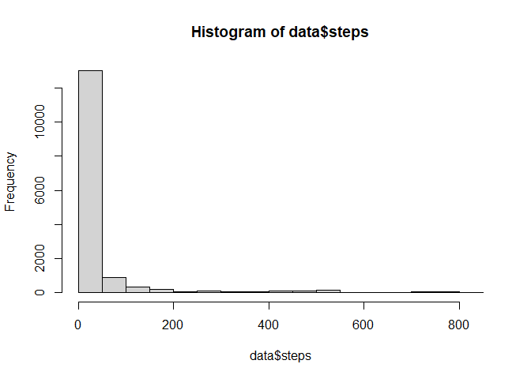

```r
hist(data$steps)
```

```r
#Median of the number of step per day
med_step_by_day <- median(data$steps, na.rm = TRUE)
med_step_by_day
```

```
## [1] 0
```

```r
#Mean of the number of step per day
mean_step_by_day <- mean(data$steps,na.rm = TRUE)
mean_step_by_day
```

```
## [1] 37.3826
```

# 2. Time series

## 2.1. Create time serie

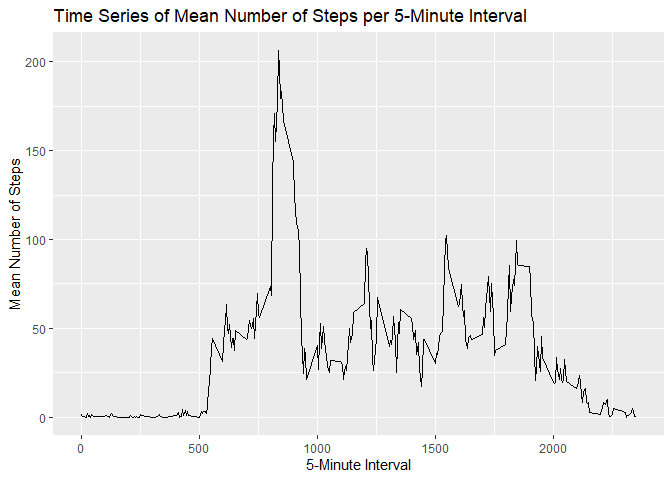

```r
# Convert the 'interval' column to a numeric format
data$interval <- as.numeric(data$interval)

# Aggregate data by interval and calculate the mean steps
mean_by_interval <- data %>%
  group_by(interval) %>%
  summarize(mean_steps = mean(steps, na.rm = TRUE))

# Plot the time series
ggplot(mean_by_interval, aes(x = interval, y = mean_steps, group = 1)) +
  geom_line(type = "l") +
  labs(x = "5-Minute Interval", y = "Mean Number of Steps") +
  ggtitle("Time Series of Mean Number of Steps per 5-Minute Interval")
```

## 2.2. Find the interval which contains the maximum of steps made

```r
#create a matrix which contains the mean of step for  each interval
interval_means <- tapply(data$steps, data$interval,function(x) mean(na.omit(x)))


# Convert interval_means matrix into dataframe
df_interval_means <- data.frame(
      interval = as.numeric(names(interval_means)),
      mean_steps = as.numeric(interval_means))


# Find the 5-minute interval with the highest value of steps
max_steps_interval <- df_interval_means$interval[which.max(df_interval_means$mean_steps)]

# Display the result
cat("The 5-minute interval with the highest number of steps is:", max_steps_interval, "\n")
```

```
## The 5-minute interval with the highest number of steps is: 835
```

# 3. Missing values imputation

## 3.1. Calculate the number of missing values on all data file

```r
#Calculate the number of missing values
sum_na <- sum(is.na(data))

# Display the number of missing values
cat("The number of missing values into the dataframe data is:", sum_na, "\n")
```

```
## The number of missing values into the dataframe data is: 2304
```

```r
#Check where the missing values are
cat("Number of missing values in 'steps' column: ", sum(is.na(data$steps)),
    " - Number of missing values in 'date' column: ", sum(is.na(data$date)),
    " - Number of missing values in 'interval' column: ", sum(is.na(data$interval)), "\n")
```

```
## Number of missing values in 'steps' column:  2304  - Number of missing values in 'date' column:  0  - Number of missing values in 'interval' column:  0
```

## 3.2. Replace missing values

First thing to do, create a new data frame with the original data frame “data”. This new data frame will name “data_no_na” because it will contain no missing values.

```r
data_no_na <- data
```

In order to find and replace missing values we followed the next methodology. First, we created a matrix, thanks to taplly function, which contains the mean of each interval. Second, we put the data of this matrix into a data frame with 2 columns. One column with the interval data and a second column with the mean for each interval Third, we created with the function “for” a function which verify if the data into data$steps is a NA or no. If the data is a NA, then the data is replace by the corresponding interval of the data.

```r
# Calculate the mean of steps for each interval
interval_means <- tapply(data_no_na$steps, data_no_na$interval, function(x) mean(x, na.rm = TRUE))


# Convert interval_means into dataframe
df_interval_means <- data.frame(
      interval = as.numeric(names(interval_means)),
      mean_steps = as.numeric(interval_means))


# Find and replace all NA values
for (i in seq_along(data_no_na$steps)) {
      if (is.na(data_no_na$steps[i])) {
            interval_of_na <- data_no_na$interval[i]
            data_no_na$steps[i] <- df_interval_means$mean_steps[df_interval_means$interval == interval_of_na]
      }
}
```

## 3.3. Histogram without NA

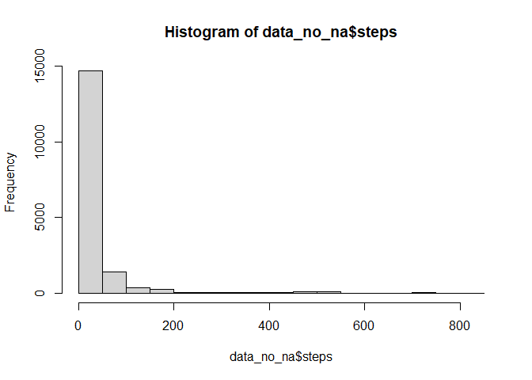

```r
##Histogram of the number of steps taken per day
hist(data_no_na$steps)
```

```r
#Median of the number of step per day
med_step_by_day_no_na <- median(data_no_na$steps)
med_step_by_day_no_na
```

```
## [1] 0
```

```r
#Mean of the number of step per day
mean_step_by_day_no_na <- mean(data_no_na$steps)
mean_step_by_day_no_na
```

```
## [1] 37.3826
```

```r
#Sum of steps
sum(data_no_na$steps)
```

```
## [1] 656737.5
```

## 3.5. Comparison with the values of data frame “data”

```r
#Comparison bewteen the mean
mean_step_by_day == mean_step_by_day_no_na
```

```
## [1] TRUE
```

```r
#Comparison bewteen the median
med_step_by_day == med_step_by_day_no_na
```

```
## [1] TRUE
```

```r
#Comparison between the sum
sum(data$steps, na.rm = TRUE) == sum(data_no_na$steps)
```

```
## [1] FALSE
```

```r
sum(data$steps, na.rm = TRUE) > sum(data_no_na$steps)
```

```
## [1] FALSE
```

The median and mean values between the two data frame, with or without missing values, are not different. However, the sum of steps is higher into the data frame without missing values. This result is normal because we replaced the missing values by new values, which increase consequently the total number of steps.

# 4. Difference between week days and week end ?

## 4.1 Create a new column to indicate if the data corresponds to week days or week end

```r
# Convert the column date into a date class
data_no_na$date <- as.Date(data_no_na$date)

# Use the function mutate to create a new column which indicade if the date correspond to a week day or to week end. I use a french R studio version. Consequently the date are in french "lundi,mardi...." and not in english.
data_no_na <- data_no_na %>%
  mutate(day = ifelse(weekdays(date) %in% c("lundi", "mardi", "mercredi", "jeudi", "vendredi"), "day of the week", "week-end"))

# Check the new column day
table(data_no_na$day)
```

```
##
## day of the week        week-end
##           12960            4608
```

## 4.2.Variation of mean step between day of the week and week-end

```r
#Create a file which contains the mean steps depending to the interval and the day
mean_by_interval_day <- data_no_na %>%
      group_by(interval, day) %>%
      summarize(mean_steps = mean(steps, na.rm = TRUE))
```

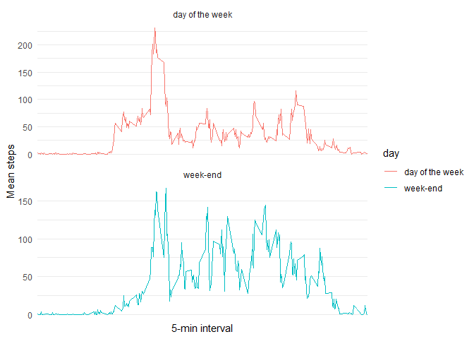

```r
#Create a figure to show, with time series, the variation of mean steps between weekend and day of the week
ggplot(mean_by_interval_day, aes(x = interval, y = mean_steps, group = day, color = day)) +
      geom_line() +
      facet_wrap(~day, scales = "free_y",nrow = 2) +
      labs(x = "5-min interval", y = "Mean steps") +
      scale_x_discrete(breaks = seq(0, 2355, by = 500))+
      theme_minimal()
```